# Chapter 06: Multiple Linear Regression

Runnable workbook for Regression with R and Python

This runnable workbook supplements the reference workbook. It adds setup code and lightweight fixes so the chapter can usually be rendered and run end-to-end.

- Runnable companion script: R/chapter06.R
- Reference workbook: chapter06_workbook.Rmd
- Textbook chapter: `Multiple Linear Regression`
- Package installation lines are shown as comments and are not run automatically during rendering.

## Multiple regression in R

### Box 01

Textbook context: Section: The general multiple linear regression model.

```r
 df <- read.csv("apartment_price_data.csv")
```

### Box 02

Textbook context: Section: The general multiple linear regression model.

```r
 ols_model <- lm(price ~ living_area + monthly_fee +
 new_production, data=df)
```

### Box 03

Textbook context: Section: The general multiple linear regression model.

```r
    library("lmtest")
    library("sandwich")
    rob_inf <- coeftest(ols_model,
      vcov = vcovHC(ols_model, type = "HC0"))
```

### Box 04

Textbook context: Section: The general multiple linear regression model.

```r
      lmtest::coefci(ols_model,
  vcov. = vcovHC(ols_model, type = "HC0"),
  level = 0.95)
```

```
#>                        2.5 %        97.5 %
#> (Intercept)     1.0370277326  1.6388502311
#> living_area     0.0256065889  0.0481016660
#> monthly_fee    -0.0006142887 -0.0002888475
#> new_production -0.3372325910  0.1373152870
```

### Box 05

Textbook context: Section: The general multiple linear regression model.

```r
 b1 <- rob_inf["living_area", "Estimate"]
 se1 <- rob_inf["living_area", "Std. Error"]
 t_stat <- (b1 - 0.04) / se1
 df_model <- ols_model$df.residual
 p_value <- (1 - pt(abs(t_stat), df_model)) * 2
```

## Added-variable plot in R

### Box 06

Textbook context: Section: Regression anatomy and partial regression plots | Subsection: Added-variable plots.

```r
df <- read.csv("apartment_price_data.csv")

res_y <- residuals(lm(price ~ monthly_fee, data=df))
res_x <- residuals(lm(living_area ~ monthly_fee, data=df))

av_model <- lm(res_y ~ res_x)
coef(av_model)
```

```
#>   (Intercept)         res_x
#> -3.020594e-17  3.679946e-02
```

```r
coef(lm(price ~ living_area + monthly_fee, data=df))
```

```
#>   (Intercept)   living_area   monthly_fee
#>  1.3325957328  0.0367994550 -0.0004506754
```

### Box 07

Textbook context: Section: Regression anatomy and partial regression plots | Subsection: Added-variable plots.

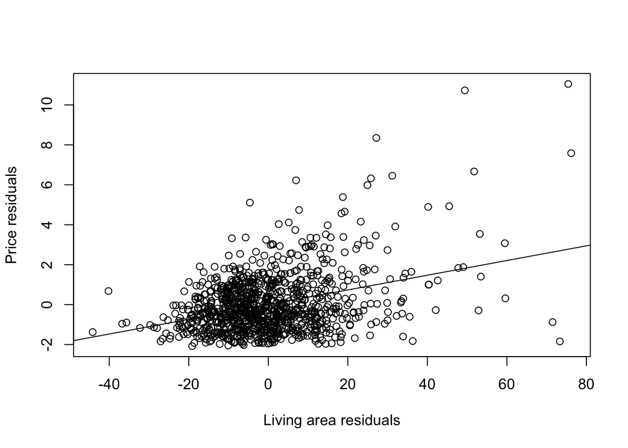

```r
plot(res_x, res_y,
     xlab = "Living area residuals",
     ylab = "Price residuals")
abline(av_model)
```

## $F$-test in R

### Box 08

Textbook context: Section: $F$-test.

```r
 ols_model_l <- lm(price ~ living_area + monthly_fee +
  new_production + build_year, data=df)
 summary(ols_model_l)
```

```
#>
#> Call:
#> lm(formula = price ~ living_area + monthly_fee + new_production +
#>     build_year, data = df)
#>
#> Residuals:
#>     Min      1Q  Median      3Q     Max
#> -4.0612 -1.0201 -0.1734  0.7913  8.3899
#>
#> Coefficients:
#>                  Estimate Std. Error t value Pr(>|t|)
#> (Intercept)     1.666e+01  3.243e+00   5.138 3.39e-07 ***
#> living_area     3.688e-02  3.189e-03  11.565  < 2e-16 ***
#> monthly_fee    -3.785e-04  5.989e-05  -6.320 4.08e-10 ***
#> new_production  3.108e-01  3.368e-01   0.923    0.356
#> build_year     -7.914e-03  1.670e-03  -4.740 2.48e-06 ***
#> ---
#> Signif. codes:  0 '***' 0.001 '**' 0.01 '*' 0.05 '.' 0.1 ' ' 1
#>
#> Residual standard error: 1.395 on 920 degrees of freedom
#>   (75 observations deleted due to missingness)
#> Multiple R-squared:  0.1554, Adjusted R-squared:  0.1517
#> F-statistic: 42.32 on 4 and 920 DF,  p-value: < 2.2e-16
```

### Box 09

Textbook context: Section: $F$-test.

```r
    n <- nobs(ols_model_l)
```

### Box 10

Textbook context: Section: $F$-test.

```r
    b <- !is.na(df$new_production) & !is.na(df$build_year)
```

### Box 11

Textbook context: Section: $F$-test.

```r
    ols_model_s <- lm(price ~ living_area + monthly_fee,
                              data=df[b, ])
```

### Box 12

Textbook context: Section: $F$-test.

```r
    residuals_l <- residuals(ols_model_l)
    residuals_s <- residuals(ols_model_s)
    RSS_l <- sum(residuals_l^2)
    RSS_s <- sum(residuals_s^2)
```

### Box 13

Textbook context: Section: $F$-test.

```r
    K <- 4
    G <- 2
```

### Box 14

Textbook context: Section: $F$-test.

```r
    F_obs <- ((RSS_s - RSS_l) / (K - G)) /
             (RSS_l / (n - (K + 1)))
```

### Box 15

Textbook context: Section: $F$-test.

```r
 p <- 1 - pf(F_obs, df1=K-G, df2=n-(K+1))
```

### Box 16

Textbook context: Section: $F$-test.

```r
    anova(ols_model_s, ols_model_l)
```

```
#> Analysis of Variance Table
#>
#> Model 1: price ~ living_area + monthly_fee
#> Model 2: price ~ living_area + monthly_fee + new_production + build_year
#>   Res.Df    RSS Df Sum of Sq      F    Pr(>F)
#> 1    922 1833.5
#> 2    920 1789.7  2    43.736 11.241 1.502e-05 ***
#> ---
#> Signif. codes:  0 '***' 0.001 '**' 0.01 '*' 0.05 '.' 0.1 ' ' 1
```

### Box 17

Textbook context: Section: $F$-test.

```r
 summary(ols_model_l)
```

```
#>
#> Call:
#> lm(formula = price ~ living_area + monthly_fee + new_production +
#>     build_year, data = df)
#>
#> Residuals:
#>     Min      1Q  Median      3Q     Max
#> -4.0612 -1.0201 -0.1734  0.7913  8.3899
#>
#> Coefficients:
#>                  Estimate Std. Error t value Pr(>|t|)
#> (Intercept)     1.666e+01  3.243e+00   5.138 3.39e-07 ***
#> living_area     3.688e-02  3.189e-03  11.565  < 2e-16 ***
#> monthly_fee    -3.785e-04  5.989e-05  -6.320 4.08e-10 ***
#> new_production  3.108e-01  3.368e-01   0.923    0.356
#> build_year     -7.914e-03  1.670e-03  -4.740 2.48e-06 ***
#> ---
#> Signif. codes:  0 '***' 0.001 '**' 0.01 '*' 0.05 '.' 0.1 ' ' 1
#>
#> Residual standard error: 1.395 on 920 degrees of freedom
#>   (75 observations deleted due to missingness)
#> Multiple R-squared:  0.1554, Adjusted R-squared:  0.1517
#> F-statistic: 42.32 on 4 and 920 DF,  p-value: < 2.2e-16
```

## Robust $F$-test in R

### Box 18

Textbook context: Section: $F$-test | Subsection: Robust $F$-test.

```r
    library("lmtest")
    library("sandwich")
```

### Box 19

Textbook context: Section: $F$-test | Subsection: Robust $F$-test.

```r
    waldtest(ols_model_s, ols_model_l,
             vcov = vcovHC(ols_model_l, type = "HC0"))
```

```
#> Wald test
#>
#> Model 1: price ~ living_area + monthly_fee
#> Model 2: price ~ living_area + monthly_fee + new_production + build_year
#>   Res.Df Df      F   Pr(>F)
#> 1    922
#> 2    920  2 5.9509 0.002705 **
#> ---
#> Signif. codes:  0 '***' 0.001 '**' 0.01 '*' 0.05 '.' 0.1 ' ' 1
```

## Confidence intervals for expected value and prediction intervals in R

### Box 20

Textbook context: Section: Uncertainty of the conditional expectation | Subsection: Prediction interval.

```r
 ols_model <- lm(price ~ living_area, data=df)
 x0 <-80
 yhat_x80 <- predict(ols_model,
 newdata=data.frame(living_area=x0))
```

### Box 21

Textbook context: Section: Uncertainty of the conditional expectation | Subsection: Prediction interval.

```r
  n <- nobs(ols_model)
  RSS <- sum(residuals(ols_model)^2)
  s2_epsilon <- RSS / (n - 2)
  xbar <- mean(df$living_area)
  SSX <- sum((df$living_area - xbar)^2)
  var_eY_x0 <- s2_epsilon * (1 / n + (x0 - xbar)^2 / SSX)
```

### Box 22

Textbook context: Section: Uncertainty of the conditional expectation | Subsection: Prediction interval.

```r
 alpha <- 0.05
 t_crit <- qt(1-alpha/2, df=n-2)
 lb_ci_eY_x0 <- yhat_x80 - t_crit * sqrt(var_eY_x0)
 ub_ci_eY_x0 <- yhat_x80 + t_crit * sqrt(var_eY_x0)
```

### Box 23

Textbook context: Section: Uncertainty of the conditional expectation | Subsection: Prediction interval.

```r
 var_tildeepsilon_x0 <- var_eY_x0 + s2_epsilon
 lb_pi_x0 <- yhat_x80 - t_crit * sqrt(var_tildeepsilon_x0)
 ub_pi_x0 <- yhat_x80 + t_crit * sqrt(var_tildeepsilon_x0)
```

### Box 24

Textbook context: Section: Uncertainty of the conditional expectation | Subsection: Prediction interval.

```r
 ols_model2 <- lm(price ~ living_area + monthly_fee +
 new_production, data=df)
```

### Box 25

Textbook context: Section: Uncertainty of the conditional expectation | Subsection: Prediction interval.

```r
 eval_df <- data.frame(living_area=80,
 monthly_fee=3000, new_production=1)
 predict(ols_model2, newdata = eval_df,
 interval = "confidence",
 level=.95)
```

```
#>        fit      lwr      upr
#> 1 2.831606 2.448967 3.214245
```

```r
 predict(ols_model2, newdata = eval_df,
 interval = "prediction",
 level=.95)
```

```
#>        fit        lwr      upr
#> 1 2.831606 0.09714409 5.566068
```